# **Trend of Violent Discipline Among Children Aged 1–14 Years**

Author

Shreyansh Mohta

Published

2024-04-27

[output not shown]

#**Introduction** Child violence remains a hidden epidemic impacting millions globally. UNICEF’s latest data on violent discipline practices reveals alarming rates of abuse across countries. By visualizing these patterns, we aim to raise public awareness, inform policymakers, and advocate for safer childhoods worldwide. Every child deserves a life free from violence.

#**World Map Chart** This world map reveals the global spread of violent discipline. Countries with higher rates are vividly highlighted, making it easy to recognize regional disparities. The visualization showcases how child violence is not limited to one area but is a widespread issue requiring international attention and immediate policy action.

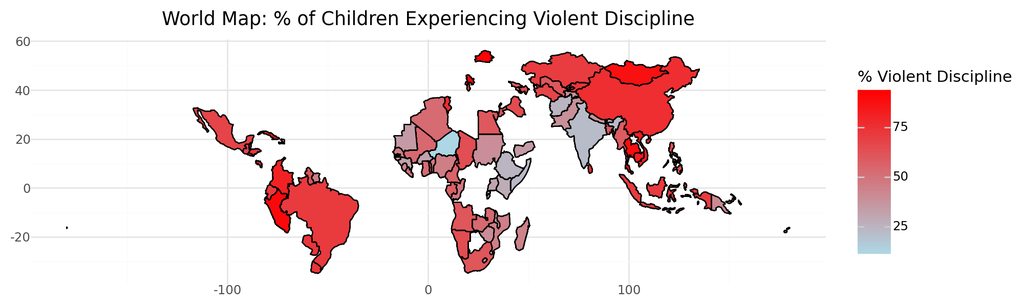

[figure not shown]

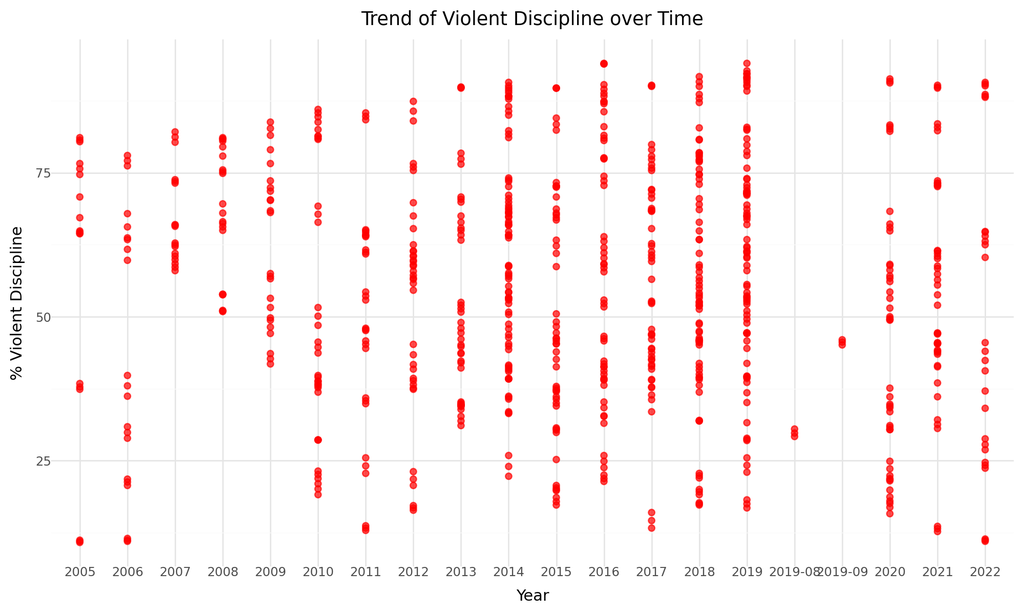

#**Density Plot** The density plot visualizes the spread of violent discipline rates across countries. Most nations cluster around moderate violence levels, but significant peaks suggest worrying concentrations. This visualization reveals that while extreme cases are fewer, the majority of countries face substantial child welfare challenges requiring urgent global intervention and systemic change.

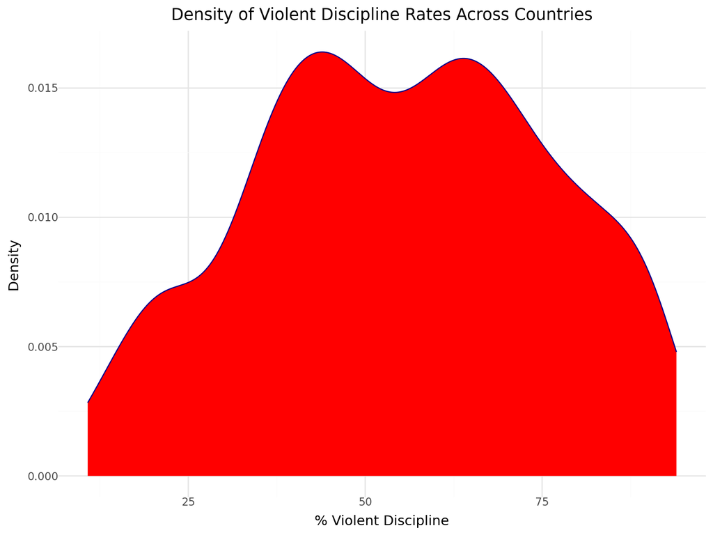